# Homework summary by 22003

Jiaqiang Li

2022-11-29

## HW0-0909

### Question

Use knitr to produce at least 3 examples (texts, figures, tables).

### Answer

First we see how to to show a picture.

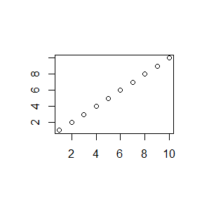

```r
plot(1:10,1:10,xlab="",ylab="")
```

Then let we see how to show table using knitr. We show the last six lines in Freedman data set.

```r
data_now <- carData::Freedman
knitr::kable(tail(data_now),format = "html",caption="Table1: Freeedman Dataset")
```

Table1: Freeedman Dataset

|  | population | nonwhite | density | crime |
| --- | --- | --- | --- | --- |
| Wichita | 406 | 5.8 | 166 | 2532 |
| Wilkes | 340 | 0.3 | 383 | 613 |
| Wilmington | 488 | 11.7 | 419 | 2393 |
| Worcester | 612 | 0.9 | 405 | 2874 |
| York | 316 | 2.0 | 220 | 1062 |
| Youngstown | 528 | 9.2 | 513 | 1698 |

Furthermore, we can use the package kableExtra to make our table more beautiful.

```r
table2 <- knitr::kable(tail(data_now),format = "html",caption="Table2: Freeedman Dataset")

table2 <- kableExtra::row_spec(table2,0, color = "white", background = "#696969" )
# Set the fill method of the header

table2 <- kableExtra::column_spec(table2,5,color=ifelse(data_now$crime[105:110]>2500,"red","black"),bold=data_now$crime[105:110]>2500)
# Bold the number of crimes greater than 2500 in red

kableExtra::kable_styling(table2,bootstrap_options = "bordered",full_width = F,font_size=20)
```

Table2: Freeedman Dataset

|  | population | nonwhite | density | crime |
| --- | --- | --- | --- | --- |
| Wichita | 406 | 5.8 | 166 | 2532 |
| Wilkes | 340 | 0.3 | 383 | 613 |
| Wilmington | 488 | 11.7 | 419 | 2393 |
| Worcester | 612 | 0.9 | 405 | 2874 |
| York | 316 | 2.0 | 220 | 1062 |
| Youngstown | 528 | 9.2 | 513 | 1698 |

```r
# Use bootstrap_options="bordered" to set borders for the table
# "full_width=F" contols the table's width such that it won't fill the whole page
# We can use font_size to set the font size in table
```

Finally, we use “cat” to output texts and use summary to see Freedman dataset.

```r
cat("Freedman Summary\n")
```

Freedman Summary

```r
pander::pander(summary(data_now))
```

| population | nonwhite | density | crime |
| --- | --- | --- | --- |
| Min. : 270.0 | Min. : 0.30 | Min. : 37.0 | Min. : 458 |
| 1st Qu.: 398.8 | 1st Qu.: 3.40 | 1st Qu.: 266.5 | 1st Qu.:2067 |
| Median : 664.0 | Median : 7.20 | Median : 412.0 | Median :2698 |
| Mean : 1136.0 | Mean :10.80 | Mean : 765.7 | Mean :2714 |
| 3rd Qu.: 1167.8 | 3rd Qu.:14.88 | 3rd Qu.: 773.2 | 3rd Qu.:3305 |
| Max. :11551.0 | Max. :64.30 | Max. :13087.0 | Max. :5441 |
| NA’s :10 | NA | NA’s :10 | NA |

```r
# We can also use pander to show tables.
```

## HW1-0915

### Question

The Pareto(a, b) distribution has cdf

$$F(x)=1-(\frac{b}{x})^a,\quad x\geq
b>0,a>0$$
Derive the probability inverse transformation $F^{-1}(U)$ and use the inverse transform method to simulate a random sample from the Pareto(2, 2) distribution. Graph the density histogram of the sample with the Pareto(2, 2) density superimposed for comparison.

### Answer

By definition,

```r
set.seed(15)
u <- runif(n=5000,min=0,max=1) # generate U
pareto <- 2/sqrt(1-u)          # generate Pareto(2,2)
```

We graph the density histogram of the sample as below. Besides, we know that Pareto(2,2) has density $f(x)=\frac{16}{x^3}1(x\geq 2)$. We graph this density using red lines in the picture.

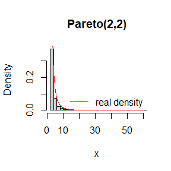

```r
hist(pareto,probability = T,xlim=c(2,60),breaks = 100,main="Pareto(2,2)",xlab="x")
x <- seq(2,60,length.out=1000)
lines(x,16/x^3,col="red") # line the density of Pareto(2,2)
legend("bottomright",legend = "real density", col="red",lty=1,bty="n")
```

The histogram is consistent with the real density.

### Question

Write a function to generate a random sample of size n from the Beta(a, b) distribution by the acceptance-rejection method. Generate a random sample of size 1000 from the Beta(3,2) distribution. Graph the histogram of the sample with the theoretical Beta(3,2) density superimposed.

### Answer

The density of Beta(a,b) is

$$f_{ab}(x)=\frac{1}{B(a,b)}x^a(1-x)^b\leq
\frac{1}{B(a,b)},\quad 0<x<1,$$
We can take $g(y)=1(0<y<1)$ and $c=B(a,b)^{-1}$ such that $f_{ab}(x)\leq cg(x)$. We generate Beta(a,b) as following:

Generate $U,Y \sim U(0,1)$;  
Compute $\rho(Y)=\frac{f_{ab}(Y)}{cg(Y)}$;  
If $U\leq \rho(Y)$ return $X=Y$,  
otherwise reject $Y$ and continue.

```r
# gen_beta generate samples from Beta(a,b) using the acceptance-rejection method
gen_beta <- function(a,b,n){
  # a,b the parameters of B(a,b)
  # n the number of samples
  count <- 0
  x <- numeric(n)
  c <- 1/beta(a,b)
  while(count < n){
    u <- runif(1)
    y <- runif(1) # random variable from g(.)
    if(y^a*(1-y)^b >= u){
      # accept y
      count<-count+1
      x[count] <- y
    }
  }
  return(x)
}
```

Now let we generate 1000 samples from the Beta(3,2).

```r
set.seed(7)
beta_user <- gen_beta(3,2,1000)
```

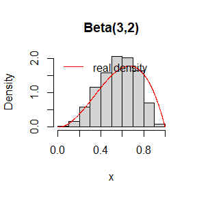

```r
hist(beta_user,main="Beta(3,2)",probability = T,breaks = 12,xlab="x")
x <- seq(0,1,length.out=1000)
lines(x,x^2*(1-x)/beta(3,2),col="red") # line the density of Beta(3,2)
legend("topleft",legend = "real density", col="red",lty=1,bty="n")
```

### Question

Simulate a continuous Exponential-Gamma mixture. Suppose that the rate parameter $\Lambda$ has $Gamma(r, \beta)$ distribution and $Y$ has $Exp(\Lambda)$ distribution. That is, $(Y |\Lambda = \lambda) ∼ f_Y (y|\lambda) = \lambda e^{−\lambda y}$. Generate 1000 random observations from this mixture with $r = 4$ and $\beta = 2$.

### Answer

We write a function ‘gen_expgamma’ to generate a continuous Exponential-Gamma mixture.

```r
gen_expgamma <- function(r,b,n){
  # r,b the parameter of lambda
  # n the size of samples
  lambda <- rgamma(n,r,b) # generate lambda from Gamma(r,b)
  y <- sapply(1:n,function(i) rexp(1,lambda[i])) # generate Y
  return(y)
}

# Generate samples
set.seed(15)
expg_user <- gen_expgamma(4,2,1000)
```

Let we have a look at its distribution through histogram.

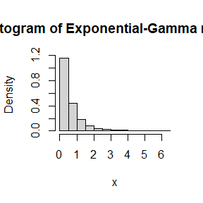

```r
hist(expg_user,probability  = T,xlab="x",main="Histogram of Exponential-Gamma mixture")
```

### Question

Compare the performance of the Beta generator of Exercise 3.7, Example 3.8 and the R generator rbeta. Fix the parameters a = 2, b = 2 and time each generator on 1000 iterations with sample size 5000. (See Example 3.19.) Are the results different for different choices of a and b?

### Answer

We write a function ‘gen_beta_byg’ to generate Beta(a,b) as Example 3.8.

```r
gen_beta_byg <- function(a,b,n){
  u <- rgamma(n,a,1)
  v <- rgamma(n,b,1)
  x <- u/(u+v)
  return(x)
}
```

```r
n <- 1000 # sample size
rep <- 100 # iterations
a <-b<-2 # parameters

set.seed(15)
t1 <- system.time(for (i in 1:rep)
  gen_beta(a,b,n))
set.seed(15)
t2 <- system.time(for (i in 1:rep)
  gen_beta_byg(a,b,n))
set.seed(15)
t3 <- system.time(for (i in 1:rep)
  rbeta(n,a,b))
m22 <- matrix(c(t1,t2,t3),nrow=3,byrow=T)[,1:3]
rownames(m22) <- c("beta_accept_reject","beta_from_gamma","rbeta")
colnames(m22) <- c("user", "system", "elapsed")
knitr::kable(m22,caption = "a=2,b=2")
```

a=2,b=2

|  | user | system | elapsed |
| --- | --- | --- | --- |
| beta_accept_reject | 8.15 | 1.57 | 9.72 |
| beta_from_gamma | 0.03 | 0.00 | 0.03 |
| rbeta | 0.03 | 0.00 | 0.03 |

Let we consider the following two cases: a=3,b=2 and a=2,b=1. Their acceptance rates are 0.083 and 0.5. And the acceptance rates for Beta(2,2) is 0.167. So we can find that accept-reject method in Beat(3,2) is slower than it in Beta(2,2). And accept-reject method in Beat(2,1) is faster than it in Beta(2,2). Although accept-reject method is the slowest method in all cases.

```r
a<-3
b<-2
set.seed(15)
t1 <- system.time(for (i in 1:rep)
  gen_beta(a,b,n))
set.seed(15)
t2 <- system.time(for (i in 1:rep)
  gen_beta_byg(a,b,n))
set.seed(15)
t3 <- system.time(for (i in 1:rep)
  rbeta(n,a,b))

m32 <- matrix(c(t1,t2,t3),nrow=3,byrow=T)[,1:3]
rownames(m32) <- c("beta_accept_reject","beta_from_gamma","rbeta")
colnames(m32) <- c("user", "system", "elapsed")
knitr::kable(m32,caption = "a=3,b=2")
```

a=3,b=2

|  | user | system | elapsed |
| --- | --- | --- | --- |
| beta_accept_reject | 16.03 | 0.45 | 16.48 |
| beta_from_gamma | 0.01 | 0.00 | 0.02 |
| rbeta | 0.00 | 0.00 | 0.00 |

```r
a<-2
b<-1
set.seed(15)
t1 <- system.time(for (i in 1:rep)
  gen_beta(a,b,n))
set.seed(15)
t2 <- system.time(for (i in 1:rep)
  gen_beta_byg(a,b,n))
set.seed(15)
t3 <- system.time(for (i in 1:rep)
  rbeta(n,a,b))

m21 <- matrix(c(t1,t2,t3),nrow=3,byrow=T)[,1:3]
rownames(m21) <- c("beta_accept_reject","beta_from_gamma","rbeta")
colnames(m21) <- c("user", "system", "elapsed")
knitr::kable(m21,caption = "a=2,b=1")
```

a=2,b=1

|  | user | system | elapsed |
| --- | --- | --- | --- |
| beta_accept_reject | 3.19 | 0.02 | 3.20 |
| beta_from_gamma | 0.01 | 0.00 | 0.01 |
| rbeta | 0.01 | 0.00 | 0.02 |

## HW2-0923

### Fast sorting

**Problem.**

$\cdot$ For $n=10^4,2\times 10^4,4\times 10^4,6\times 10^4, 8\times 10^4,$ apply the fast sorting algorithm to randomly permuted numbers of $1,\dots,n.$

$\cdot$ Calculate computation time averaged over 100 simulations, denoted by $a_n$.

$\cdot$ Regress $a_n$ on $t_n:=n\log n$, and graphically show the results (scater plot and regression line).

**Solution.** We implement fast sorting using the function ‘quick_sort’ from Professor Zhang’s slides.

```r
quick_sort<-function(x){
  # sorting function
  num<-length(x)
  if(num==0||num==1){return(x)
  }else{
    a<-x[1]
    y<-x[-1]
    lower<-y[y<a]
    upper<-y[y>=a]
    return(c(quick_sort(lower),a,quick_sort(upper)))} # Recursion
}

sample_num <- c(1e4,2e4,4e4,6e4,8e4)

simu_sort <- function(i){
  # simulation function
  set.seed(i)
  time <- sapply(1:5,function(j) system.time(quick_sort(sample(1:sample_num[j])))[1])
  return(time)
}

# Calculate computation time averaged over 100 simulations
times <- sapply(1:100,simu_sort)
an <- rowMeans(times)
names(an)<-as.character(sample_num)
```

Then let we look the relations ship between the time and sample numbers. The red line is the regression line.

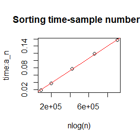

```r
tn <- sample_num*log(sample_num)
reg <- lm(an~tn,data=data.frame(tn,an)) # linear regression

# scatter plot and regressino line
plot(tn,an,xlab="nlog(n)",ylab="time:a_n",main="Sorting time-sample numbers")
abline(a=reg$coefficients[1],b=reg$coefficients[2],col="red")
```

We can find that
$$a_n \propto
n\log{n}$$

### Exercise 5.6

**Problem.** In Example 5.7 the control variate approach was illustrated for Monte Carlo integration of

$$\theta = \int_0^1 e^x dx$$

Now consider the antithetic variate approach. Compute $\operatorname{Cov}(e^U, e^{1−U})$ and $\operatorname{Var}(e^U+e^{1−U})$, where $U\sim \operatorname{Uniform}(0,1)$. What is the percent reduction in variance of $\hat{\theta}$ that can be achieved using antithetic variates (compared with simple MC)?

**Solution.**

Denote $T_1=e^U, T_2=e^{1-U}$, then $\mathbb{E}T_1=\mathbb{E}T_2=\theta$. SO the sample means for $T_1$ and $T_2$ are unbiased estimations for $\theta$.

$$\begin{aligned}\operatorname{Cov}(T_1,T_2)&=\int_0^1e^x\times
e^{1-x}dx-\left(\int_0^1 e^x dx\right)^2\\&=3e-e^2-1.
\end{aligned}$$

$$\begin{aligned}\operatorname{Var}(T_1+T_2)&=\operatorname{Var}(T_1)+\operatorname{Var}(T_2)+2\operatorname{Cov}(T_1,T_2)\\
&=2\times\left(\frac{e^2-1}{2}-(e-1)^2\right)+2\times
\left(e-(e-1)^2\right)\\
&=10e-3e^2-5
\end{aligned}$$

For $m$ replicates, the variance of simple MC is $\operatorname{Var}(T_1)/m$. The variance of antithetic variate approach is $\operatorname{Var}(T_1+T_2)/4m$.

The simple MC estimator is

$$\hat{\theta}=\frac 1m\sum_{i=1}^m
e^{U_i},$$
and the antithetic variate approach estimator is

$$\tilde{\theta}=\frac{1}{2m}\sum_{i=1}^m(e^{U_i}+e^{1-U_i}).$$

Theoretical percent reduction in variance using the antithetic variate compared with the simple Monte Carlo estimate is
$$1-\frac{\operatorname{Var}(\tilde{\theta})}{\operatorname{Var}(\hat{\theta})}=1-\frac{10e-3e^2-5}{4(\frac{e^2-1}{2}-(e-1)^2)}=98.3835\%$$

### Exercise 5.7

**Problem.** Refer to Exercise 5.6. Use a Monte Carlo simulation to estimate $\theta$ by the antithetic variate approach and by the simple Monte Carlo method. Compute an empirical estimate of the percent reduction in variance using the antithetic variate. Compare the result with the theoretical value from Exercise 5.6.

**Solution.** Using the estimator $\hat{\theta}$ and $\tilde{\theta}$ in Exercise 5.6, we use MC method to compute empirically the percent reduction.

```r
m <- 10000
set.seed(15)
U <- runif(m)
T1 <- exp(U) # simple MC
T12 <- (exp(1-U)+T1)/2 # antithetic
```

The result using simple MC is

```r
mean(T1)
```

```
## [1] 1.725018
```

The result using antithetic variate method is

```r
mean(T12)
```

```
## [1] 1.718679
```

The emperical percent variance reduction is

```r
(var(T1)-var(T12))/var(T1)
```

```
## [1] 0.9839142
```

It’s suggested that the theoretical percent reduction $98.3835\%$ is approximately achieved in this simulation.

## HW3-0930

### Exercise 5.13

**Problem.**

Find two importance functions $f_1$ and $f_2$ that are supported on $(1,\infty)$ and are ‘close’ to

$$g(x)=\frac{x^2}{\sqrt{2\pi}}e^{-x^2/2},\quad
x>1.$$

Which of your two importance functions should produce the smaller variance in estimating

$$\int_1^{\infty}\frac{x^2}{\sqrt{2\pi}}e^{-x^2/2}dx$$

by importance sampling? Explain.

**Solution.**

The candidates for the importance function are

$$\begin{aligned}
f_1(x)&=\frac{1}{\sqrt{2\pi}}e^{-x^2/2},\quad
-\infty<x<\infty,\\
f_2(x)&=\frac{1}{2}x^2e^{-x},\quad 0<x<\infty,
\end{aligned}$$

where $f_1$ is density function for $N(0,1)$ and $f_2$ is density for $\Gamma(3,1)$.

```r
g <-function(x) x^2/sqrt(2*pi)*exp(-x^2/2)*(x>1)

f1 <- function(x) 1/sqrt(2*pi)*exp(-x^2/2)

f2 <- function(x) x^2*exp(-x)/2
```

We use importance sampling to calculate the integration.

```r
m <- 10000
theta.hat <- se<- numeric(2)
fg<-matrix(0,nrow=2,ncol=m)

# using f1
set.seed(15)
x <- rnorm(m)
fg[1,] <- g(x)/f1(x)
theta.hat[1] <-mean(fg[1,])
se[1] <- sd(fg[1,])

# using f2
set.seed(15)
x <- rgamma(m,3,1)
fg[2,] <- g(x)/f2(x)
theta.hat[2] <-mean(fg[2,])
se[2] <- sd(fg[2,])
```

The estimates (labeled theta.hat) of $\int_1^{\infty} g(x)dx$ and the corresponding standard errors se for the simulation using each of the importance functions are:

```r
rbind(theta.hat,se)
```

```
##                [,1]      [,2]
## theta.hat 0.4021799 0.3956735
## se        1.1255863 0.4559163
```

The simulation indicates that $f_2$ produce smaller variance than $f_1$. Because $f_1$ is supported on the entire real line, while $g$ is supported only on $(1,\infty)$. There are a vary large number of zeros (more than 75%) produced in the ratio $g(x)/f(x)$, and all other values far from 0, resulting in a large variance. But the ratio for $f_2$ is less than 25%. So $f_2$ performs better than $f_1$. The following summary statistics for the ratio $g(x)/f_1(x)$ and $g(x)/f_2(x)$ confirm this.

```r
summary(fg[1,])
```

```
##    Min. 1st Qu.  Median    Mean 3rd Qu.    Max.
##  0.0000  0.0000  0.0000  0.4022  0.0000 14.5766
```

```r
summary(fg[2,])
```

```
##     Min.  1st Qu.   Median     Mean  3rd Qu.     Max.
## 0.000000 0.002145 0.159973 0.395674 0.767270 1.315489
```

### Exercise 5.15

**Problem.** Obtain the stratified importance sampling estimate in Example 5.13 and compare it with the result of Example 5.10.

**Solution.**

We need to estimate $\theta = \int_0^1\frac{e^{-x}}{1+x^2}dx$.

The best results in Example 5.13 is obtained by the importance function
$$f_3(x)=e^{-x}/(1-e^{-1}),\quad
0<x<1,$$
corresponding codes are in below:

```r
m <- 10000
g <- function(x) exp(-x)/(1+x^2)*(x>0)*(x<1)
f <- function(x){ exp(-x)/(1-exp(-1))*(x>0)*(x<1)}

# f3, inverse transform method
set.seed(15)
u <- runif(m)
x <- -log(1-u*(1-exp(-1)))
fg <- g(x)/f(x)
theta.im <- mean(fg)
se.im <-sd(fg)
```

In this way $\hat{\theta}_1=$ 0.5234 with $se(\hat{\theta}_1)=$ 0.0972.

Then we cut the interval as 5-folds: $\left(F^{-1}((j-1)/5),F^{-1}(j/5)\right),j=1,\dots,5$. On the $j^{th}$ subinterval variables are generated from the density

$$\frac{5e^{-x}}{1-e^{-1}}\times1\left(F^{-1}((j-1)/5)<x<
F^{-1}(j/5)\right),$$

where $F^{-1}(t)=-\log\left(1-(1-e^{-1})t\right)$.

Consider $U_j\sim U[\frac {j-1}{5},\frac{j}{5}],j=1,\dots,5$ and $\int_0^X\frac{e^{-t}}{1-e^{-1}}dt=U_j$. Then we know X have the density $\frac{5e^{-x}}{1-e^{-1}}\times1\left(F^{-1}((j-1)/5)<x< F^{-1}(j/5)\right).$

Now let we use transformation method to implement stratified importance sampling.

```r
set.seed(15)
k<-5
n<-m/k
theta_s <- var_s <-numeric(k)
for(i in 1:k){
  u <- runif(n,(i-1)/5,i/5)
  x <- -log(1-(1-exp(-1))*u)
  fg <- g(x)/k/f(x)
  theta_s[i]<-mean(fg)
  var_s[i]<-var(fg)
}
```

The $\hat{\theta}$ is

```r
sum(theta_s)
```

```
## [1] 0.5246954
```

And $se(\hat{\theta})$ is

```r
sqrt(sum(var_s))
```

```
## [1] 0.00938088
```

which is less than one-tenth of simple importance sampling method ($se(\hat{\theta}_1)=$ 0.0972).

## HW4-1009

### Exercise 6.4

**Problem.**

Suppose that $X_1, \dots , X_n$ are a random sample from a from a lognormal distribution with unknown parameters. Construct a 95% confidence interval for the parameter $\mu$. Use a Monte Carlo method to obtain an empirical estimate of the confidence level.

**Solution.**

Suppose $\ln X_i\sim N(\mu,\sigma^2)$, then $\sqrt{n}(\overline{\ln X}-\mu)/\sigma\sim N(0,1)$, $S^2/\sigma^2\sim \chi^2_{n-1}$ and $S^2$ is independent with $\overline{\ln X}$, where
$$S^2=\frac{1}{n-1}\sum(\ln
X_i-\overline{\ln X})^2.$$
So we know $\sqrt{n}(\overline{\ln X}-\mu)/S\sim t_{n-1}$. Then a 95% CI for $\mu$ is
$$\overline{\ln
X}\pm\frac{t_{n-1}(0.025)}{\sqrt{n(n-1)}}\sqrt{\sum_{i=1}^n(\ln
X_i-\overline{\ln X})^2}.$$

Now we use MC to calculate it. We generate $X_1,\dots,X_n$ from lognormal distribution with $\mu=0,\sigma=1$.

```r
gen_lognorm <- function(n,mu,sigma){
# n the number of samples
y <- rnorm(n,mu,sigma)
return(exp(y))
}

# generate data
n <-10000
mu<-0
sigma <-1
set.seed(15)
x <- gen_lognorm(n,mu,sigma)
```

```r
# calculate CI
x_log <- mean(log(x))
s <- sd(log(x))
cl <- x_log-qt(0.975,n-1)/sqrt(n)*s
cu <- x_log+qt(0.975,n-1)/sqrt(n)*s
```

So the lower bound for 95% CI for $\mu$ is

```r
print(cl)
```

```
## [1] -0.02258659
```

The upper bound for 95% CI for $\mu$ is

```r
print(cu)
```

```
## [1] 0.01702729
```

We give a emperical 95% confidence interval [-0.023,0.017].

```r
# clear up memory
rm(list=ls())
gc()
```

```
##           used (Mb) gc trigger (Mb) max used (Mb)
## Ncells  843701 45.1    1586422 84.8  1586422 84.8
## Vcells 1494331 11.5    8388608 64.0  8388606 64.0
```

### Exercise 6.8

**Problem** Refer to Example 6.16. Repeat the simulation, but also compute the F test of equal variance, at significance level $\hat{\alpha}$ = 0.055. Compare the power of the Count Five test and F test for small, medium, and large sample sizes. (Recall that the F test is not applicable for non-normal distributions.)

**Solution** We use “count5test” to implement Count Five test. We use “var.test” in R to do F test.

```r
count5test <- function(x,y){
x_center <- x-mean(x)
y_center <- y-mean(y)
outx <- sum(x_center>max(y_center))+sum(x_center<min(y_center))
outy <- sum(y_center>max(x_center))+sum(y_center<min(x_center))
# return 1 (reject) or 0 (not reject H_0)
return(as.integer(max(outx,outy)>5))
}
```

First, we consider normal distribution. Consider $N(0,1^2)$ and $N(0,1.5^2)$. Repeat 10000 times.

```r
m <- 10000
# generate the data and do test
simu_norm <- function(i,n,mu,sigma1,sigma2){
# i the seed
# n the number of samples
# sigma1 standard error for X
# sigma2 standard error for y
set.seed(i)
x <- rnorm(n,mu,sigma1)
y <- rnorm(n,mu,sigma2)
# the result of count5test and F test (with confidence level equals 0.055)
test <-c(count5test(x,y),  as.integer(var.test(x,y)$p.value<0.055))
return(test)
}
```

We calculate powers for the two test in three cases: (1) small samples, $n_1=n_2=20$,(2) medium samples, $n_1=n_2=50$,(3) large samples, $n_1=n_2=100$.

```r
mu<-0
sigma1<-1
sigma2<-1.5

# power for small samples
n <- 20
power_s <- rowMeans(sapply(1:m,function(i) simu_norm(i,n,mu,sigma1,sigma2)))
# power for medium samples
n <- 50
power_m <- rowMeans(sapply(1:m,function(i) simu_norm(i,n,mu,sigma1,sigma2)))
# power for large samples
n <- 100
power_l <- rowMeans(sapply(1:m,function(i) simu_norm(i,n,mu,sigma1,sigma2)))
power_norm <- matrix(c(20,power_s,50,power_m,100,power_l),nrow=3,byrow=T)
colnames(power_norm)<-c("n","count5test","F-test")
knitr::kable(power_norm,caption = "Power for samples from norm distribution")
```

Power for samples from norm distribution

| n | count5test | F-test |
| --- | --- | --- |
| 20 | 0.3203 | 0.4203 |
| 50 | 0.6598 | 0.8134 |
| 100 | 0.8509 | 0.9825 |

F test performs better than Count Five test. Because F test assume that data is generated from normal distributions, which is consistent with the setting in this simulation.

Then we consider Gamma distributions: $\Gamma(1,1),\Gamma(0.5,0.5)$. They have the same $\mu=1$ but different variances: $\sigma_1^2=1,\sigma^2_2=2$.

```r
# generate the data and do test
simu_gamma <- function(i,n,a1,b1,a2,b2){
# i the seed
# n the number of samples
# a1,a2 shape parameters for X,y
# b1,b2 rate parameters for x,y
set.seed(i)
x <- rgamma(n,a1,b1)
y <- rgamma(n,a2,b2)
# the result of count5test and F test (with confidence level equals 0.055)
test <-c(count5test(x,y),  as.integer(var.test(x,y)$p.value<0.055))
return(test)
}
```

```r
a1 <-b1<-1
a2<-b2<-0.5

# power for small samples
n <- 20
power_s <- rowMeans(sapply(1:m,function(i) simu_gamma(i,n,a1,b1,a2,b2)))
# power for medium samples
n <- 50
power_m <- rowMeans(sapply(1:m,function(i) simu_gamma(i,n,a1,b1,a2,b2)))
# power for large samples
n <- 100
power_l <- rowMeans(sapply(1:m,function(i) simu_gamma(i,n,a1,b1,a2,b2)))

power_gamma <- matrix(c(20,power_s,50,power_m,100,power_l),nrow=3,byrow=T)
colnames(power_gamma)<-c("n","count5test","F-test")
knitr::kable(power_gamma,caption = "Power for samples from gamma distribution")
```

Power for samples from gamma distribution

| n | count5test | F-test |
| --- | --- | --- |
| 20 | 0.6329 | 0.4305 |
| 50 | 0.8197 | 0.5937 |
| 100 | 0.8865 | 0.7477 |

## HW5-1014

### Exercise 7.4

**Problem.**

Refer to the air-conditioning data set air-conditioning provided in the boot package. The 12 observations are the times in hours between failures of air-conditioning equipment [63, Example 1.1]:
$$3, 5, 7, 18, 43, 85, 91, 98,100, 130, 230,
487.$$
Assume that the times between failures follow an exponential model $Exp(\lambda)$. Obtain the MLE of the hazard rate $\lambda$ and use bootstrap to estimate the bias and standard error of the estimate.

**Solution.**

Suppose we have samples $X_1,\dots,X_n,\text{i.i.d.}\sim Exp(\lambda)$ then their likelihood is
$$L(X_1,\dots,X_n)=\lambda^ne^{-\lambda\sum_{i=1}^nX_i}1(\lambda>0).$$

Note that $\frac{d\log L}{d\lambda}=\frac{n}{\lambda}-\sum_{i=1}^nX_i$, which is monotonic w.r.t. $\lambda$. Let $\frac{d\log L}{d\lambda}=0$,we know that
$$\hat{\lambda}_{MLE}=\frac{n}{\sum_{i=1}^nX_i}.$$

We use the formule to obtain $\hat{\lambda}_{MLE}.$

```r
time_fail <- c(3, 5, 7, 18, 43, 85, 91, 98,100, 130, 230, 487)
lambda_mle <-length(time_fail)/sum(time_fail)
cat("The MLE of the hazard rate is ", round(lambda_mle,5),".")
```

```
## The MLE of the hazard rate is  0.00925 .
```

Ten we use bootstrap to estimate the bias and standard error of the estimate.

```r
B <- 1e4 # times for bootstrap
lambda_b <-numeric(B)
set.seed(99)
# bootstrap
for(i in 1:B){
  lambda_b[i]<-1/mean(sample(time_fail,12,replace = T))
}

# estimate bias and se
lambda_bias <- mean(lambda_b)-lambda_mle
se.lambda <- sd(lambda_b)
```

The bias of the estimate is

```r
round(lambda_bias,5)
```

```
## [1] 0.0013
```

The standard error of the estimate is

```r
round(se.lambda,5)
```

```
## [1] 0.00425
```

```r
# clear up memory
rm(list=ls())
gc()
```

```
##           used (Mb) gc trigger (Mb) max used (Mb)
## Ncells  845557 45.2    1586422 84.8  1586422 84.8
## Vcells 1504438 11.5    8388608 64.0  8388606 64.0
```

### Exercise 7.5

**Problem** Refer to Exercise 7.4. Compute 95% bootstrap confidence intervals for the mean time between failures $1/\lambda$ by the standard normal, basic, percentile, and BCa methods. Compare the intervals and explain why they may differ.

**Solution**

We use the ‘boot’ and ‘boot.ci’ in R to calculate bootstrap confidence intervals for $1/\lambda$.

```r
library(boot)
time_fail <- c(3, 5, 7, 18, 43, 85, 91, 98,100, 130, 230, 487)
set.seed(76)
R <- 1e4
stat.b <- boot(data=time_fail, statistic=function(x,i) mean(x[i]),R=R)
# calculate CI
ci <- boot.ci(stat.b, type=c("norm","basic","perc","bca"))
```

```r
CIs <- matrix(c(ci$normal[2:3],ci$basic[4:5],ci$percent[4:5],ci$bca[4:5]),nrow=4,byrow=T)
colnames(CIs)<-c("lower","upper")
rownames(CIs) <- c("normal","basic","percentile","BCa")
```

Then 95% CIs obtained through these methods are

```r
knitr::kable(CIs,digits=3,caption = "95% CI")
```

95% CI

|  | lower | upper |
| --- | --- | --- |
| normal | 36.038 | 181.328 |
| basic | 26.167 | 169.915 |
| percentile | 46.252 | 190.000 |
| BCa | 57.894 | 222.437 |

All these CIs cover $=$108.0833333.And both the lower bound and upper bound of CIs satisfy
$$basic<normal<percentile<BCa$$
.

```r
# compare the length of for CIs
order(CIs[,2]-CIs[,1],decreasing = F)
```

```
## [1] 3 2 1 4
```

And the length of four CIs satisfy
$$percentile<basic<normal<BCa$$
These CIs are different because they use different assumptions or models.

Normal CI assumes that $\hat{\theta}$ is unbiased for $\theta=1/\lambda$ and the sample size is large. However, this sample size is small (only 12) and $\hat{\theta}$ may not be unbiased since the bias estimated by bootstrap is-0.6. So this CI may not be very good.

The key idea of basic CI is to estimate quantile of the bias of $\hat{\theta}:b_{\alpha/2},b_{1-\alpha/2}$.This method is to make a model for bias to some degree.

The percentile CI use the fact that $\hat{\theta}^*|X$ have the same limit distribution with $\hat{\theta}$. So the performance of this CI might not be so satisfactory when sample size is small.

BCa CI is a modified version of percentile CI. We don’t need many assumptions in this case.

```r
# clear up the memory
rm(list=ls())
gc()
```

```
##           used (Mb) gc trigger (Mb) max used (Mb)
## Ncells  862522 46.1    1586422 84.8  1586422 84.8
## Vcells 1540093 11.8    8388608 64.0  8388606 64.0
```

### Project 7.A

**Problem** Conduct a Monte Carlo study to estimate the coverage probabilities of the standard normal bootstrap confidence interval, the basic bootstrap confidence interval, and the percentile confidence interval.

Sample from a normal population and check the empirical coverage rates for the sample mean. Find the proportion of times that the confidence intervals miss on the left, and the porportion of times that the confidence intervals miss on the right.

**Solution**

We generate 50 samples from $N(0,1)$ each time and repeat 10000 times. Each time we generate 199 groups of bootstrap sample and calculate 95% confidence intervals use the three methods mentioned in the question.

```r
m <- 1e4
B <- 199
ci.norm <- ci.basic<-ci.percent <-matrix(NA,m,2)
boot_mean <- function(x,i) mean(x[i])
n<-50 # the number of samples to generate at each time
mu <- 0

# use MC to calculate CI
for(i in 1:m){
  set.seed(i)
  x <- rnorm(n,mu,1) # generate normal distribution with mean=mu and sd=1
  mean.b <- boot(x,statistic=boot_mean,R=B)

  # obtain three 95% CIs
  CIs<-boot.ci(mean.b,type=c("norm","basic","perc"))
  ci.norm[i,]<-CIs$norm[2:3]
  ci.basic[i,] <- CIs$basic[4:5]
  ci.percent[i,] <- CIs$percent[4:5]
}

rate <- matrix(nrow=3,ncol=3)
colnames(rate) <- c("coverage","miss on left","miss on right")
rownames(rate)<-c("normal","basic","percentile")

# the porportion of times that the confidence intervals miss on the left
rate[,2]<-c(sum(mu<ci.norm[,1]),sum(mu<ci.basic[,1]),sum(mu<ci.percent[,1]))/m

# the porportion of times that the confidence intervals miss on the right
rate[,3]<-c(sum(mu>ci.norm[,2]),sum(mu>ci.basic[,2]),sum(mu>ci.percent[,2]))/m

# emperical coverage rates
rate[,1]<-1-rate[,2]-rate[,3]
```

Empirical coverage rates and the proportion of times that the confidence intervals miss on the left or right is shown in the table below.

```r
knitr::kable(rate,digits=3)
```

|  | coverage | miss on left | miss on right |
| --- | --- | --- | --- |
| normal | 0.942 | 0.030 | 0.028 |
| basic | 0.942 | 0.029 | 0.029 |
| percentile | 0.944 | 0.029 | 0.027 |

```r
# clear up the memory
rm(list=ls())
gc()
```

```
##           used (Mb) gc trigger (Mb) max used (Mb)
## Ncells  862778 46.1    1586422 84.8  1586422 84.8
## Vcells 1543778 11.8    8388608 64.0  8388606 64.0
```

## HW6-1024

### Exercise 7.8

**Problem.**

Consider data in package ‘bootstrap’. The five-dimensional scores data have a $5\times 5$ covariance matrix $\Sigma$ with positive eigenvalues $\lambda_1>\cdots>\lambda_5$. Let $\hat{\lambda}_1>\cdots>\hat{\lambda}_5$ be the eigenvalues of $\hat{\Sigma}$, where $\hat{\Sigma}$ is the MLE of $\Sigma$.
$$\hat{\theta}=\frac{\hat{\lambda}_1}{\sum_{j=1}^5\hat{\lambda}_j}$$
$\hat{\theta}$ is the sample estimate for $\theta=\frac{\lambda_1}{\sum_{i=1}^5\lambda_i}$. Obtain the jackknife estimates of bias and standard error of $\hat{\theta}$

**Solution.**

```r
library(bootstrap)
# load the data
data("scor")
```

The MLE of $\Sigma$ is $\frac 1n (X_i-\bar{X})(X_i-\bar{X})^T, X_i\in R^5$ represents a student’s scores.

```r
n <- 88
# estimate theta
eigen_now <- eigen(cov(scor)*(n-1)/n)$values
theta.hat <- eigen_now[1]/sum(eigen_now)

# use jackknife to obtain bias and se of theta.hat
theta.jack <- numeric(n)
for(i in 1:n){
  eigen_now <- eigen(cov(scor[-i,])*(n-2)/(n-1))$values
  theta.jack[i] <- eigen_now[1]/sum(eigen_now)
}

bias.jack <- (n-1)*(mean(theta.jack)-theta.hat)
se.jack <- sqrt((n-1)*mean((theta.jack-mean(theta.jack))^2))
theta <- c(theta.hat,bias.jack,se.jack)
names(theta)<-c("original","bias,jack","se.jack")
```

```r
# print results
round(theta,3)
```

```
##  original bias,jack   se.jack
##     0.619     0.001     0.050
```

```r
# clear up memory
rm(list=ls())
gc()
```

```
##           used (Mb) gc trigger (Mb) max used (Mb)
## Ncells  870147 46.5    1586422 84.8  1586422 84.8
## Vcells 1560971 12.0    8388608 64.0  8388606 64.0
```

### Exercise 7.11

**Problem** In Example 7.18, leave-one-out (n-fold) cross validation was used to select the best fitting model. Use leave-two-out cross validation to compare the models.

**Solution**

```r
library(DAAG)
data("ironslag")
```

```r
attach(ironslag)
n <- length(magnetic)
l <- n*(n-1)/2 # possible cases for leave-two-out

e1 <- e2 <- e3 <- e4 <- numeric(l)
ind <-1

for(i in 1:(n-1)){
  for(j in (i+1):n){
    # leave- two-out
    inds <- c(i,j)
    y <- magnetic[-inds]
    x <- chemical[-inds]

    # linear
    m1 <- lm(y~x)
    yhat1 <- m1$coef[1]+m1$coef[2]*chemical[inds]
    e1[ind] <- mean((magnetic[inds]-yhat1)^2)

    # quadratic
    m2 <- lm(y~ x+I(x^2))
    yhat2 <- m2$coef[1]+m2$coef[2]*chemical[inds]+m2$coef[3]*chemical[inds]^2
    e2[ind]<-mean((magnetic[inds]-yhat2)^2)

    # exponential
    m3 <- lm(log(y) ~ x)
    logyhat3 <- m3$coef[1] + m3$coef[2] * chemical[inds]
    yhat3 <- exp(logyhat3)
    e3[ind] <- mean((magnetic[inds] - yhat3)^2)

    # log-log
    m4 <- lm(log(y) ~ log(x))
    logyhat4 <- m4$coef[1] + m4$coef[2] * log(chemical[inds])
    yhat4 <- exp(logyhat4)
    e4[ind] <- mean((magnetic[inds] - yhat4)^2)

    ind = ind+1
  }
}
```

The MSE obtained by CV is as below:

```r
c(mean(e1),mean(e2),mean(e3),mean(e4))
```

```
## [1] 19.57227 17.87018 18.45491 20.46718
```

It’s obvious that quadratic model is the best fitting model.

```r
# clear up the memory
rm(list=ls())
gc()
```

```
##           used (Mb) gc trigger (Mb) max used (Mb)
## Ncells  918131 49.1    1586422 84.8  1586422 84.8
## Vcells 1626325 12.5    8388608 64.0  8388606 64.0
```

### Exercise 8.2

**Problem** Implement the bivariate Spearman rank correlation test for independence [255] as a permutation test. The Spearman rank correlation test statistic can be obtained from function cor with method = “spearman”. Compare the achieved significance level of the permutation test with the p-value reported by cor.test on the same samples.

**Solution** We generate $X\sim N(0,1)$ and $Y=X^3$. We test the independence for $X,Y$. Generate $n=100$ samples.

```r
# generate data
set.seed(129)
x <- rnorm(100)
y <- x^3
```

```r
library(StatComp22003)
z<-matrix(c(x,y),ncol=2)

spearman <- function(z,ix){
  x <- z[,1] # leave x as it is
  y <- z[ix,2] #permute rows of y
  return(cor(x,y,method = "spearman"))
}

# permutation
permu <- boot(data=z,statistic = spearman,R=999,sim="permutation")
tb <- c(permu$t0,permu$t)

# p-value for permutation test
p <- mean(abs(tb)>=abs(tb[1]))
p
```

```
## [1] 0.001
```

```r
cor.test(x,y)
```

```
##
##  Pearson's product-moment correlation
##
## data:  x and y
## t = 12.805, df = 98, p-value < 2.2e-16
## alternative hypothesis: true correlation is not equal to 0
## 95 percent confidence interval:
##  0.7041563 0.8547449
## sample estimates:
##       cor
## 0.7911511
```

The p-value reported by is less than 2.2e-16 which is much less than p-value reported by permutation test which is 0.001.

```r
# clear up the memory
rm(list=ls())
gc()
```

```
##           used (Mb) gc trigger (Mb) max used (Mb)
## Ncells  925886 49.5    1586422 84.8  1586422 84.8
## Vcells 1644868 12.6    8388608 64.0  8388606 64.0
```

## HW7-1028

### Exercise 9.4

**Problem.**

Implement a random walk Metropolis sampler for generating the standard Laplace distribution (see Exercise 3.2). For the increment, simulate from a normal distribution. Compare the chains generated when different variances are used for the proposal distribution. Also, compute the acceptance rates of each chain.

**Solution.**

We use $N(X_t,\sigma^2)$ as proposal distribution to generate the standard Laplace distribution, the acceptance probability is

$$\alpha(X_{i},Y)=\min
(e^{|X_i|-|Y|},1).$$

We consider $\sigma=0.5,1,2,4$. For each $\sigma$, we generate $k=5$ chains with length $N=5000$ and initial value $-10,-5,0,5,10$. We take $\psi(X_1,\dots,X_n)=\frac 1n \sum_{i=1}^n X_i$ to monitor the convergence of chains.

#### Functions used

```r
# generate a chain
rw.laplace <- function(x0, N, sigma){
  # x0 initiial value
  # N the length of the chain
  # sigma sd for proposal distribution
  x <- numeric(N)
  x[1] <- x0
  u <- runif(N)
  k <- 0 # count acceptance cases
  for (i in 2:N) {
    y <- rnorm(1, x[i-1], sigma)
    if (u[i] <= exp(abs(x[i-1])-abs(y))){
      x[i] <- y
      k <- k+1
    }else {
      x[i] <- x[i-1]

    }
  }
   return(list(x=x, k=k))
}

# calculate $\hat{R}$ to monitor convergence
cal.GR <- function(psi){
  # psi[i,j] is the diagnostic statistic psi(X[i,1:j])
  # for chain in i-th row of X

  n <- ncol(psi)
  k <- nrow(psi)

  psi.means <- rowMeans(psi)
  B <- n*var(psi.means)  # between variance est.
  psi.w <- apply(psi, 1, var)
  W <- mean(psi.w)        # within variance est.
  v.hat <- W*(n-1)/n+B/n  # var(psi) est.
  r.hat <- sqrt(v.hat/W)  # G-R statistic
  return(r.hat)
 }
```

#### Generate chains

```r
x0 <- c(-10,-5,0,5,10)
sigmas <- c(0.5,1,2,4)
k <- 5
N <- 5000 # length of chains
b <- 500 # burn-in lenght
X <- list("s1"=matrix(nrow=k,ncol=N),"s2"=matrix(nrow=k,ncol=N),"s3"=matrix(nrow=k,ncol=N),"s4"=matrix(nrow=k,ncol=N)) # collect chains
accept <- matrix(nrow=length(sigmas), ncol=k) # record acceptance rate for each chain


set.seed(225)
for(i in 1:k){

  mc <- rw.laplace(x0[i],N,sigmas[1])
  X$s1[i,] <- mc$x
  accept[1,i] <- mc$k/N

  mc <- rw.laplace(x0[i],N,sigmas[2])
  X$s2[i,] <- mc$x
  accept[2,i] <- mc$k/N

  mc <- rw.laplace(x0[i],N,sigmas[3])
  X$s3[i,] <- mc$x
  accept[3,i] <- mc$k/N

  mc <- rw.laplace(x0[i],N,sigmas[4])
  X$s4[i,] <- mc$x
  accept[4,i] <- mc$k/N
}
```

#### Monitor convergence

```r
psi <- list("s1"=matrix(nrow=k,ncol=N),"s2"=matrix(nrow=k,ncol=N),"s3"=matrix(nrow=k,ncol=N),"s4"=matrix(nrow=k,ncol=N))
R.hat <-list("s1"=numeric(N),"s2"=numeric(N),"s3"=numeric(N),"s4"=numeric(N))
psi$s1 <- t(apply(X$s1,1,cumsum))
psi$s2 <- t(apply(X$s2,1,cumsum))
psi$s3 <- t(apply(X$s3,1,cumsum))
psi$s4 <- t(apply(X$s4,1,cumsum))

for(i in 1: k){

  # calculate the statistic psi
  psi$s1[i,] <- psi$s1[i,]/(1:N)
  psi$s2[i,] <- psi$s2[i,]/(1:N)
  psi$s3[i,] <- psi$s3[i,]/(1:N)
  psi$s4[i,] <- psi$s4[i,]/(1:N)

  for(j in (b+1):N){
    R.hat$s1[j] <- cal.GR(psi$s1[,1:j])
    R.hat$s2[j] <- cal.GR(psi$s2[,1:j])
    R.hat$s3[j] <- cal.GR(psi$s3[,1:j])
    R.hat$s4[j] <- cal.GR(psi$s4[,1:j])
  }

}
```

#### Show results

```r
accept <- cbind(sigmas,accept)
colnames(accept) <- c("sigma","x0=-10","x0=-5","x0=0","x0=5","x0=10")
knitr::kable(round(accept,3),caption="Acceptance rates")
```

Acceptance rates

| sigma | x0=-10 | x0=-5 | x0=0 | x0=5 | x0=10 |
| --- | --- | --- | --- | --- | --- |
| 0.5 | 0.827 | 0.818 | 0.826 | 0.832 | 0.832 |
| 1.0 | 0.688 | 0.689 | 0.686 | 0.703 | 0.699 |
| 2.0 | 0.535 | 0.516 | 0.524 | 0.519 | 0.510 |
| 4.0 | 0.340 | 0.335 | 0.335 | 0.334 | 0.345 |

From the table, it’s obvious that the acceptance rate is decreasing as $\sigma$ increases. And the initial value $x_0$ seems to have no significant impact on acceptance rate under the same $\sigma$.

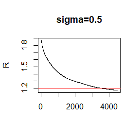

```r
plot(R.hat$s1[(b+1):N],type="l",xlab="",ylab="R",main="sigma=0.5")
abline(h=1.2,col="red")
```

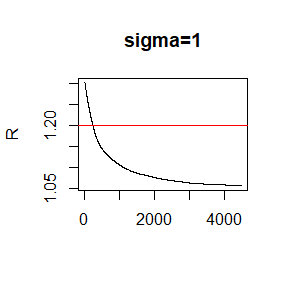

```r
plot(R.hat$s2[(b+1):N],type="l",xlab="",ylab="R",main="sigma=1")
abline(h=1.2,col="red")
```

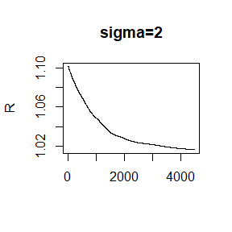

```r
plot(R.hat$s3[(b+1):N],type="l",xlab="",ylab="R",main="sigma=2")
abline(h=1.2,col="red")
```

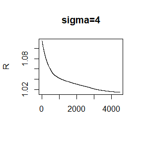

```r
plot(R.hat$s4[(b+1):N],type="l",xlab="",ylab="R",main="sigma=4")
abline(h=1.2,col="red")
```

From the pictures, we find that all the chains achieve convergence. It seems that the convergence is achieved faster with a bigger $\sigma$.

```r
# clean up the memory
rm(list=ls())
gc()
```

```
##           used (Mb) gc trigger (Mb) max used (Mb)
## Ncells  927463 49.6    1586422 84.8  1586422 84.8
## Vcells 1651225 12.6    8417606 64.3  8417606 64.3
```

### Exercise 9.7

**Problem**

Implement a Gibbs sampler to generate a bivariate normal chain $(X_t, Y_t)$ with zero means, unit standard deviations, and correlation 0.9. Plot the generated sample after discarding a suitable burn-in sample. Fit a simple linear regression model $Y = \beta_0 + \beta_1X$ to the sample and check the residuals of the model for normality and constant variance.

**Solution**

The target distribution is bivariate normal $(X,Y)\sim N(0,\Sigma), \Sigma_{11}=\Sigma_{22}=1,\Sigma_{12}=\Sigma_{21}=0.9$. The condition distributions are

$$\begin{aligned}
X_1|X_2&\sim N(0.9x_2,0.19),\\
X_2|X_1&\sim N(0.9x_1,0.19).
\end{aligned}$$

We take $\psi(X_1,\dots,X_n;Y_1,\dots,Y_n)=\frac 1 n \sum_i X_iY_i-\bar{X}\bar{Y}$ to monitor the convergence of chains.

#### Functions used

```r
N <- 5000
k <- 4
X <- matrix(nrow=k, ncol=N)
Y <- matrix(nrow=k, ncol=N)
sd <- sqrt(0.19)
rho <- 0.9
Gibbs.gen <- function(x0,y0,N){
  x <- numeric(N)
  y <- numeric(N)
  x[1] <- x0
  y[1] <- y0

  u <- runif(N)
  k <- 0 # count acceptance cases
  for (i in 2:N) {
    x[i] <- rnorm(1, rho*y[i-1], sd)
    y[i] <- rnorm(1,rho*x[i],sd)

  }
  return(cbind(x,y))
}

# calculate $\hat{R}$ to monitor convergence
cal.GR <- function(psi){
  # psi[i,j] is the diagnostic statistic psi(X[i,1:j])
  # for chain in i-th row of X

  n <- ncol(psi)
  k <- nrow(psi)

  psi.means <- rowMeans(psi)
  B <- n*var(psi.means)  # between variance est.
  psi.w <- apply(psi, 1, var)
  W <- mean(psi.w)        # within variance est.
  v.hat <- W*(n-1)/n+B/n  # var(psi) est.
  r.hat <- sqrt(v.hat/W)  # G-R statistic
  return(r.hat)
 }
```

#### Generate chains and monitor convergence

```r
x0 <- -2:1
y0 <- 2:-1
# take x0,y0 as initial value, we generate k chains with length N
b <-1000 # burn-in length
psi <- matrix(0,nrow=k,ncol=N)

set.seed(17)
# generate chains
for(i in 1:k){
  xy <- Gibbs.gen(x0[i],y0[i],N)
  X[i,] <- xy[,1]
  Y[i,] <- xy[,2]
  # calculate psi
  psi[i,] <- sapply(1:N, function(j) mean(X[i,1:j]*Y[i,1:j])-mean(X[i,1:j])*mean(Y[i,1:j]))
}



R.hat <- numeric(N)
for(k in (b+1):N){
  R.hat[k] <- cal.GR(psi[,1:k])
}
```

#### Linear regression and show results

We take the chain with initial value (-2,2) as an example to plot generated sample and fit the linear regression model.

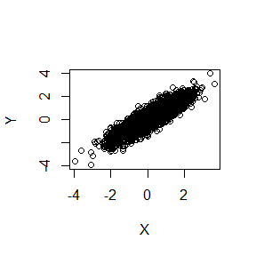

```r
plot(x=X[1,-(1:b)],y=Y[1,-(1:b)],xlab="X",ylab="Y")
```

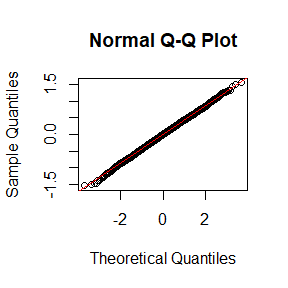

```r
# linear regression
x=X[1,-(1:b)]
y=Y[1,-(1:b)]
lmfit <- lm(y~x)

qqnorm(lmfit$residuals)
qqline(lmfit$residuals,col="red")
```

From Q-Q plot, we find that the residuals of the model are normality. And the variance of residual is

```r
var(lmfit$residuals)
```

```
## [1] 0.1913045
```

It’s very close to the therotical variance $0.19$.

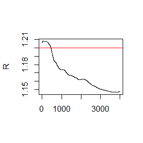

```r
plot(R.hat[-(1:b)],xlab="",ylab="R",type="l")
abline(h=1.2,col="red")
```

```r
# clear up the memory
rm(list=ls())
gc()
```

```
##           used (Mb) gc trigger (Mb) max used (Mb)
## Ncells  928773 49.7    1586422 84.8  1586422 84.8
## Vcells 1656287 12.7    8430941 64.4  8430941 64.4
```

## HW8-1104

### Exercise 1

**Solution.**

We consider $X\sim N(5,1)$, $M=a_M+\alpha X+e_M$,$Y=a_Y+\beta M+\gamma X + e_Y$,$e_M,e_Y \stackrel{i.i.d.}{\sim}N(0,1)$. We take $a_M=a_Y=1$, consider three kinds scenarios:

| Scenario | $\alpha$ | $\beta$ | $\gamma$ |
| --- | --- | --- | --- |
| 1 | 0 | 0 | 1 |
| 2 | 0 | 1 | 1 |
| 3 | 1 | 0 | 1 |

```r
# function to generate data
gen_xmy <- function(n,alpha,beta,gamma=1){
  # n number of samples
  x <- rnorm(n,5,1)
  em <- rnorm(n,0,1)

  am <- 1
  ay <- 1
  m <- am +alpha*x+em

  y <- ay + beta*m + gamma*x + rnorm(n)

  return(data.frame("X"=x,"M"=m,"Y"=y))
}

# calculate alpha_hat and beta_hat
cal_a <- function(X,M){
  data <- data.frame(X,M)
  # data is generated by gen_xmy with three components: X,M,Y
  a <- lm(M~X,data=data)$coefficients["X"] # alpha_hat

  return(a)
}

cal_b <- function(X,M,Y){
  data <- data.frame(X,M,Y)
  # data is generated by gen_xmy with three components: X,M,Y

  b <- lm(Y~X+M,data=data)$coefficients["M"] #beta_hat
  return(b)
}
```

We take the confidence level $\alpha_c=0.05$ and calculate type 1 error rates. Consider the number of samples $n=20,50,100,200.$ For each permutation test we replicate $R=199$ times.

```r
n <- c(20,50,100,200)
R<-199
```

Note that we can’t take $T=\frac{\hat{\alpha}\hat{\beta}}{\hat{se}(\hat{\alpha}\hat{\beta})}$ as test statistic. Because in one test we only have one $\hat{\alpha}$ and one $\hat{\beta}$, we can’t calculate $\hat{se}(\hat{\alpha}\hat{\beta}))$. We will take $T'=|\hat{\alpha}\hat{\beta}|$ as our statistic for hypothesis test.We permute $M$ and calculate $\hat{\alpha},\hat{\beta}$ with unpermuted X,Y.

```r
# We use perm to do permutation test
perm <- function(x,m,y,R=199){
  ns <- length(x)
  inds <- t(sapply(1:R,function(i) sample(1:ns,ns))) # permute indices
  t0 <- abs(cal_a(x,m)*cal_b(x,m,y))
  tp <- sapply(1:R,function(i) abs(cal_a(x[inds[i,]],m)*cal_b(x,m[inds[i,]],y))) # calculate T' for permutated data
  ts <- c(t0,tp)
  p.value <- mean(ts>t0)
  return(list("pvalue"=p.value,"t0"=t0,"tp"=tp))
}



# simulation fcn
simu <- function(i,n,alpha,beta,R=199){
  set.seed(i)
  data <- gen_xmy(n,alpha,beta,1)
  p <- perm(data$X,data$M,data$Y,R=R)$pvalue
  return(p)
}
```

Then we do simulation for $n=20,50,100,200$ under three scenarios. We repeate 100 times for each case.

```r
test_result1 <- matrix(nrow=length(n),ncol=100)
test_result2 <- matrix(nrow=length(n),ncol=100)
test_result3 <- matrix(nrow=length(n),ncol=100)

for(k in 1:length(n)){
  test_result1[k,] <- sapply(1:100,function(i) simu(i,n[k],0,0))<0.05
  test_result2[k,] <- sapply(1:100,function(i) simu(i,n[k],0,1))<0.05
  test_result3[k,] <- sapply(1:100,function(i) simu(i,n[k],1,0))<0.05
}
```

Now let we see type one error in three scenarios.

```r
m <- matrix(nrow=3,ncol=4)
m[1,]<-rowMeans(test_result1)
m[2,]<-rowMeans(test_result2)
m[3,]<-rowMeans(test_result3)
rownames(m) <- c("scenario 1","scenario 2","scenario 3")
colnames(m) <- as.character(n)
knitr::kable(round(m,5),caption="Type I error")
```

Type I error

|  | 20 | 50 | 100 | 200 |
| --- | --- | --- | --- | --- |
| scenario 1 | 0.02 | 0.07 | 0.05 | 0.05 |
| scenario 2 | 0.44 | 0.67 | 0.72 | 0.76 |
| scenario 3 | 0.60 | 0.82 | 0.83 | 0.87 |

From the table, we find that type I error can be controlled in scenario 1 ($\alpha=\beta=0$) but fail for scenario 2,3 because in these scenarios taking $T=\hat{a}\hat{b}$ doesn’t make sence.

```r
# clean up the memory
rm(list=ls())
gc()
```

```
##           used (Mb) gc trigger (Mb) max used (Mb)
## Ncells  929698 49.7    1586426 84.8  1586426 84.8
## Vcells 1662525 12.7    8430941 64.4  8430941 64.4
```

### Exercise 2

**Solution**

We use ‘cal_alpha’ to calculate $\alpha$.

```r
g <- function(alpha,N,b1,b2,b3,f0){
  tmp <- exp(-alpha-b1*x1-b2*x2-b3*x3)
  p <- 1/(1+tmp)
  mean(p)-f0
}

cal_alpha <- function(N=1e6,b1=0,b2=1,b3=-1,f0){
  uniroot(g,c(-12,0),N=N,b1=b1,b2=b2,b3=b3,f0=f0)$root
}
```

Now we generate data.

```r
set.seed(225)
N<-1e6
x1 <- rpois(N,1)
x2 <- rexp(N,1)
x3 <- rbinom(N,1,0.5)
```

We calculate $\alpha$ for $f_0=0.1,0.01,0.001,0.0001$.

```r
f0 <- c(0.1,0.01,0.001,0.0001)
alpha <- sapply(1:4, function(i) cal_alpha(1e6,0,1,-1,f0[i]))
```

We plot $\alpha-\log(f_0)$:

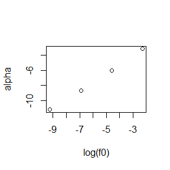

```r
plot(x=log(f0),y=alpha)
```

From the scatter plot, we find that $\alpha\propto\log(f_0)$ .

```r
# clean up the memory
rm(list=ls())
gc()
```

```
##           used (Mb) gc trigger (Mb) max used (Mb)
## Ncells  931428 49.8    1586426 84.8  1586426 84.8
## Vcells 1668114 12.8    8430941 64.4  8430941 64.4
```

## HW9-1111

### Class Work

**Problem.**

Suppose $X_1,\dots, X_n \sim Exp(\lambda),i.i.d.$ We don’t know the exact value of $X_i$. The only thing we know is that $X_i \in (u_i,v_i)$ where $u_i,v_i$ are constants. These data is called interval-censored data.

(1)Maximizing the likelihood of observed data and taking EM procedure to obtain the MLE of $\lambda$ separately. Prove that $\hat{\lambda}_{MLE}$s obtained from these two methods are equal.

(2)Suppose the observations of $(u_i,v_i)$,$i=1,\dots,n(=10)$ are $(11,12),(8,9),(27,28),(13,14),(16,17),(0,1),(23,24),(10,11),(24,25),(2,3).$ Coding to obtain $\hat{\lambda}_{MLE}$ use the above methods.

**Solution.**

(1)Denote $\mathcal{D}=\{(u_i,v_i),i=1,\dots,n\}$. The observed data log-likelihood is

$$\begin{align*}
L(\lambda|\mathcal{D})=&\prod_{i=1}^nP(u_i<X_i<v_i)=\prod_i
(e^{-\lambda u_i}-e^{-\lambda v_i}),\\
l(\lambda|\mathcal{D})=&\log L=\sum_i \log(e^{-\lambda
u_i}-e^{-\lambda v_i}),\\
\text{Let } \frac{\partial l}{\partial \lambda}=&0, \text{we have
}\\
\sum_{i=1}^n&\frac{u_ie^{-\lambda u_i}-v_ie^{-\lambda
v_i}}{e^{-\lambda u_i}-e^{-\lambda v_i}}=0.\quad (1)
\end{align*}$$

In EM procedure, the full log-likelihood is
$$\begin{aligned}
l(\lambda|\mathcal{D},X_1,\dots,&X_n)=n\log \lambda-\lambda\sum_i
X_i,\\
E_{\lambda_0}[X_i|\mathcal{D}]&=E_{\lambda_0}[X_i|u_i<X_i<v_i]\\
&=\frac{E_{\lambda_0}[X_i]-P_{\lambda_0}(X_i\leq
u_i)E_{\lambda_0}[X_i|X_i\leq u_i]-P_{\lambda_0}(X_i\geq
v_i)E_{\lambda_0}[X_i|X_i\geq v_i]}{P_{\lambda_0}(u_i<X_i<v_i)}\\
&=\frac{1}{\lambda}+\frac{u_ie^{-\lambda_0 u_i}-v_ie^{-\lambda_0
v_i}}{e^{-\lambda_0 u_i}-e^{-\lambda_0 v_i}},\\
\text{then the E-step }&\text{will be}\\
Q(\lambda|\lambda_0)&=E_{\lambda_0}[l(\lambda|\mathcal{D},X_1,\dots,X_n)|\mathcal{D}]\\
&=n\log
\lambda-\lambda\left(\frac{n}{\lambda_0}-\sum_i\frac{u_ie^{-\lambda_0
u_i}-v_ie^{-\lambda_0 v_i}}{e^{-\lambda_0 u_i}-e^{-\lambda_0
v_i}}\right),\\
\text{let }\frac{\partial Q}{\partial \lambda}=0,\text{we}&\text{
have}\\
\frac{n}{\lambda}-\frac{n}{\lambda_0}-&\sum_i\frac{u_ie^{-\lambda_0
u_i}-v_ie^{-\lambda_0 v_i}}{e^{-\lambda_0 u_i}-e^{-\lambda_0 v_i}}=0,\\
\text{then the iteration step will be}\\
\lambda_{k+1}&=n\left(\frac{n}{\lambda_k}+\sum_i\frac{u_ie^{-\lambda_k
u_i}-v_ie^{-\lambda_k v_i}}{e^{-\lambda_k u_i}-e^{-\lambda_k
v_i}}\right)^{-1},\quad (2)\\
\text{let }k\to\infty, \text{then } \lambda_{\infty} \text{
satisify}& (1).\\
\end{aligned}$$

Then we proove that the solution of (1) is unique.

Denote $g(\lambda)=\sum_{i=1}^n\frac{u_ie^{-\lambda u_i}-v_ie^{-\lambda v_i}}{e^{-\lambda u_i}-e^{-\lambda v_i}}$, then
$$g'(\lambda)=-\sum_i\frac{(u_i-v_i)^2e^{-\lambda(u_i+v_i)}}{(e^{-\lambda
u_i}-e^{-\lambda v_i})^2}>
0$$
Because $\lim_{\lambda\to 0^+}g(\lambda)=-\infty,\lim_{\lambda\to -\infty}g(\lambda)=+\infty$, $g(\lambda)$ have unique zero point. So $\hat{\lambda}_{MLE}$s obtained from MLE and EM method are equal.

(2)We use function ‘dll’ to calculate $g(\lambda)$. Solving $g(\lambda)=0$ we obtain $\hat{\lambda}_{MLE}$

```r
dll<-function(lambda,u,v){
  sum((u*exp(-lambda*u)-v*exp(-lambda*v))/(exp(-lambda*u)-exp(-lambda*v)))
}
```

```r
# u[i]<X_i<v[i]
u <- c(11,8,27,13,16,0,23,10,24,2)
v <- c(12,9,28,14,17,1,24,11,25,3)
dll_root <- uniroot(dll,interval = c(0.05,0.5),u=u,v=v,tol=1e-7)
```

$\hat{\lambda}_{MLE}$ is

```r
dll_root$root
```

```
## [1] 0.07197351
```

Then we use EM method to obtain $\hat{\lambda}_{EM}$, the MLE for $\lambda$ through EM method. We update $\hat{\lambda}_k$ using (2).

```r
n <- length(u)
lambda <- 0.05 # initial value
lambda1 <- n/(n/lambda+dll(lambda,u,v))
while(abs(lambda1-lambda)>1e-7){
  lambda <- lambda1
  lambda1 <- n/(n/lambda+dll(lambda,u,v))
}
```

The $\hat{\lambda}_{EM}$ is

```r
lambda1
```

```
## [1] 0.0719735
```

We can find that the MLE of $\lambda$ obtained by likelihood and EM method is the same.

```r
# clean up the memory
rm(list=ls())
gc()
```

```
##           used (Mb) gc trigger (Mb) max used (Mb)
## Ncells  931600 49.8    1586426 84.8  1586426 84.8
## Vcells 1669084 12.8    8430941 64.4  8430941 64.4
```

### Exercise 2.1.3

**Problem 4**

Why do you need to use unlist() to convert a list to an atomic vector? Why doesn’t as.vector() work?

**Solution**

Because ‘as.vector()’ attempts to coerce its argument in to a vector of mode ‘mode’(the default is to coerce to whichever vector mode is most convenient). In this meaning, a list is already a vector. So we need to use ‘unlist()’. Let’s see an example.

```r
a<-list(1,2,3)
typeof(a)
```

```
## [1] "list"
```

```r
unlist(a)
```

```
## [1] 1 2 3
```

```r
as.vector(a)
```

```
## [[1]]
## [1] 1
##
## [[2]]
## [1] 2
##
## [[3]]
## [1] 3
```

We find that we obtain an integer vector using ‘unlist()’ and a list using ‘as.vector’. Because the default parameter ‘m’ in ‘as.vector()’ is “any” and a list is already a vector of some mode. Besides, we can set ‘m’=“integer”. Then we will obtain an integer vector.

```r
as.vector(a,mode="integer")
```

```
## [1] 1 2 3
```

```r
# clean up the memory
rm(list=ls())
gc()
```

```
##           used (Mb) gc trigger (Mb) max used (Mb)
## Ncells  931597 49.8    1586426 84.8  1586426 84.8
## Vcells 1669119 12.8    8430941 64.4  8430941 64.4
```

**Problem 5**

Why is 1 == “1” true? Why is -1 < FALSE true? Why is “one” < 2 false?

**Solution**

When we use “==”,“<”,“>” to compare two atomic element of different type, these two elements will be coerced to the most flexible type.T ypes from least to most flexible are: logical, integer, double, and character.

For 1==“1”, we actually consider whether “1”==“1” so the result is true.

For -1<FALSE, we actually consider whether -1<0 so the result is true.

For “one” <2, we actually consider whether “one”<“2” so the result is false.

### Exercise 2.3.1

**Problem 1**

What does dim() return when applied to a vector?

**Solution**

dim() returns ‘NULL’ when applied to a vector

**Problem 2**

If is.matrix(x) is TRUE, what will is.array(x) return?

**Solution**

is.array(x) will return TRUE. Because matrix is a special type of array.

### Exercise 2.4.5

**Problem 1**

What attributes does a data frame possess?

**Solution**

Data frames have a dimension attribute. Data frames can also have additional attributes such as row names and column names.

**Problem 2**

What does as.matrix() do when applied to a data frame with columns of different types?

**Solution**

The result depends on the types of the input columns.

In ‘as.matrix()’, the method for data frames will return a character matrix if there is only atomic columns and any non-(numeric/logical/complex) column, applying as.vector to factors and format to other non-character columns. Otherwise, the usual coercion hierarchy (logical < integer < double < complex) will be used, e.g., all-logical data frames will be coerced to a logical matrix, mixed logical-integer will give a integer matrix, etc.

**Problem 3**

Can you have a data frame with 0 rows? What about 0 columns?

**Solution**

Yes.

```r
data.frame(a=integer(),b=logical())
```

```
## [1] a b
## <0 rows> (or 0-length row.names)
```

In this way we create a data frame with 0 rows.

```r
data.frame(row.names = c("a","b","c"))
```

```
## data frame with 0 columns and 3 rows
```

In this way we create a data frame with 0 cols and 3 rows.

```r
# clean up the memory
rm(list=ls())
gc()
```

```
##           used (Mb) gc trigger (Mb) max used (Mb)
## Ncells  932119 49.8    1586426 84.8  1586426 84.8
## Vcells 1670540 12.8    8430941 64.4  8430941 64.4
```

## HW10-1118

### Exercise 1

**Problem.**

The function below scales a vector so it falls in the range [0, 1]. How would you apply it to every column of a data frame? How would you apply it to every numeric column in a data frame?

```r
scale01 <- function(x) {
  rng <- range(x, na.rm = TRUE)
  (x - rng[1]) / (rng[2] - rng[1])
}
```

**Solution.**

This function needs numeric input. So when call column of a data frame is numeric, we can use ‘lapply’.

```r
df <- data.frame(a=c(1,1.5,6,-5),b=c(2,3,5,10))
data.frame(lapply(df,scale01))
```

```
##           a     b
## 1 0.5454545 0.000
## 2 0.5909091 0.125
## 3 1.0000000 0.375
## 4 0.0000000 1.000
```

When we need to apply the function to numeric columns in a data frame, we can use ‘lapply’ and ‘if else’.

```r
df <- data.frame(a=c(1,1.5,6,-5),b=c(2,3,5,10), c=c("a", "b", "c", "d"))
data.frame(lapply(df,function(x) if(is.numeric(x)) scale01(x) else x))
```

```
##           a     b c
## 1 0.5454545 0.000 a
## 2 0.5909091 0.125 b
## 3 1.0000000 0.375 c
## 4 0.0000000 1.000 d
```

```r
# clean up the memory
rm(list=ls())
gc()
```

```
##           used (Mb) gc trigger (Mb) max used (Mb)
## Ncells  932301 49.8    1586426 84.8  1586426 84.8
## Vcells 1672020 12.8    8430941 64.4  8430941 64.4
```

### Exercise 2

**Problem**

Use vapply() to:

1. Compute the standard deviation of every column in a numeric data frame.
2. Compute the standard deviation of every numeric column in a mixed data frame. (Hint: you’ll need to use vapply() twice.)

**Solution**

```r
df <- data.frame(a=1:5,b=3:7,c=-1:3)
vapply(df,sd,0)
```

```
##        a        b        c
## 1.581139 1.581139 1.581139
```

```r
df$d <-c("a","b","c","d","e") # now df is a mixed data frame
vapply(df[vapply(df,is.numeric,logical(1))],sd,numeric(1))
```

```
##        a        b        c
## 1.581139 1.581139 1.581139
```

```r
# clean up the memory
rm(list=ls())
gc()
```

```
##           used (Mb) gc trigger (Mb) max used (Mb)
## Ncells  932296 49.8    1586426 84.8  1586426 84.8
## Vcells 1672073 12.8    8430941 64.4  8430941 64.4
```

### Exercise 3

**Problem**

Implement a Gibbs sampler to generate a bivariate normal chain $(X_t, Y_t)$ with zero means, unit standard deviations, and correlation 0.9.

• Write an Rcpp function.

• Compare the corresponding generated random numbers with pure R language using the function “qqplot”.

• Compare the computation time of the two functions with the function “microbenchmark”.

**Solution**

‘gibs’ generates a bivariate normal chain using pure R language. ‘gib_c’ generates a bivariate normal chain using Rcpp.

```r
library(Rcpp)
gibs <- function(s0,N=1000, b=100, cor=0.9){
  # N the length of chain
  # b burn length
  # s0 initial state
  ss <- matrix(nrow=N,ncol=2)
  ss[1,] <- s0
  sdc <- sqrt(1-cor^2)
  for(i in 2:N){
    ss[i,1] <- rnorm(1,0.9*ss[i-1,2],sdc)
    ss[i,2] <- rnorm(1,0.9*ss[i,1],sdc)
  }
  return(ss)
}

cppFunction('NumericMatrix gib_c(NumericVector s0, int N, int b, double cor) {
  NumericMatrix ss(N,2);
  ss(0,0) = s0[0];
  ss(0,1) = s0[1];
  double sdc = sqrt(1-cor*cor);
  for(int i=1; i<N; i++){
    ss(i,0) = rnorm(1,0.9*ss(i-1,1),sdc)[0];
    ss(i,1) = rnorm(1,0.9*ss(i,0),sdc)[0];
  }
  return ss;
}')
```

```r
set.seed(1596)
r_mc <- gibs(c(0,0))

set.seed(1989)
c_mc <- gib_c(c(0,0),1000,100,0.9)
```

Leaving out the burn-in samples, we compare r_mc and c_mc using ‘qqplot’.

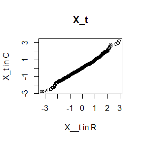

```r
b <- 100
N<-1000
qqplot(r_mc[(b+1):N,1],c_mc[(b+1):N,1],main="X_t",xlab="X__t in R",ylab="X_t in C")
```

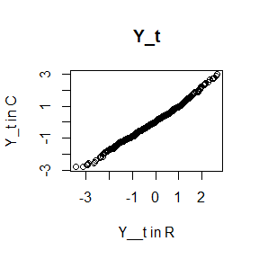

```r
qqplot(r_mc[(b+1):N,2],c_mc[(b+1):N,2],main="Y_t",xlab="Y__t in R",ylab="Y_t in C")
```

From the two qqplot, we find that ‘r_mc’ and ‘c_mc’ have the same distribution. Then we compare their computation time.

```r
library(microbenchmark)
ts <- microbenchmark(gibbsR=gibs(c(0,0)), gibbsC=gib_c(c(0,0),1000,100,0.9))
summary(ts)[,c(1,3,5,6)]
```

```
##     expr     lq median      uq
## 1 gibbsR 2846.1 2917.0 3381.25
## 2 gibbsC  218.2  223.7  231.05
```

Gibbs in C is much faster than it in R.

```r
# clean up the memory
rm(list=ls())
gc()
```

```
##           used (Mb) gc trigger (Mb) max used (Mb)
## Ncells  951163 50.8    1586426 84.8  1586426 84.8
## Vcells 1714721 13.1    8430941 64.4  8430941 64.4
```